# Optimization I

James M. Flegal

## Agenda

- Functions are objects: can be arguments for or returned by other functions
- Example: `curve()`
- Optimization via gradient descent, Newton's method, Nelder-Mead, …
- Curve-fitting by optimizing

## Functions as Objects

- In R, functions are objects, just like everything else
- This means that they can be passed to functions as arguments and returned by functions as outputs as well
- We often want to do very similar things to many different functions
- The procedure is the same, only the function we're working with changes
- Write one function to do the job, and pass the function as an argument
- Because R treats a function like any other object, we can do this simply: invoke the function by its argument name in the body

## Functions as Objects

- We have already seen examples
- `apply()`, `sapply()`, etc.: Take *this* function and use it on all of *these* objects
- `nlm()`: Take *this* function and try to make it small, starting from *here*
- `ks.test()`: Compare *these* data to *this* cumulative distribution function
- `curve()`: Evaluate *this* function over *that* range, and plot the results

## Syntax Facts About Functions

- Typing a function's name, without parentheses, in the terminal gives you its source code
- Functions are their own **class** in R

```r
class(sin)
```

```
## [1] "function"
```

```r
class(sample)
```

```
## [1] "function"
```

```r
resample <- function(x) { sample(x, size=length(x), replace=TRUE) }
class(resample)
```

```
## [1] "function"
```

## Syntax Facts About Functions

- Functions can be put into lists or even arrays
- A call to `function` returns a function object
- body executed: access with `body(foo)`
- arguments required: access with `formals(foo)`
- parent environment: access with `environment(foo)`

## Syntax Facts About Functions

R has separate **types** for built-in functions and for those written in R:

```r
typeof(resample)
```

```
## [1] "closure"
```

```r
typeof(sample)
```

```
## [1] "closure"
```

```r
typeof(sin)
```

```
## [1] "builtin"
```

Why `closure` for written-in-R functions? Because expressions are "closed" by referring to the parent environment

There's also a 2nd class of built-in functions called `primitive`

## Anonymous Functions

- `function()` returns an object of class `function`
- So far we've assigned that object to a name
- If we don't have an assignment, we get an **anonymous function**
- Usually part of some larger expression:

```r
sapply((-2):2,function(log.ratio){exp(log.ratio)/(1+exp(log.ratio))})
```

```
## [1] 0.1192029 0.2689414 0.5000000 0.7310586 0.8807971
```

## Anonymous Functions

- Often handy when connecting other pieces of code
  - especially in things like `apply` and `sapply`
- Won't cluttering the workspace
- Can't be examined or re-used later

## Example: grad()

- Many problems in statistics come down to optimization
- So do lots of problems in economics, physics, CS, biology, …
- Lots of optimization problems require the gradient of the **objective function**
- Gradient of $f$ at $x$:
  $$\nabla f(x) = \left[\left.\frac{\partial f}{\partial x_1}\right|_{x} \ldots \left.\frac{\partial f}{\partial x_p}\right|_{x}\right]$$

## Example: grad()

- We do the same thing to get the gradient of $f$ at $x$ no matter what $f$ is
- Find the partial derivative of $f$ with respect to each component of $x$ and return the vector of partial derivatives
- It makes no sense to re-write this every time we change $f$!
- Write code to calculate the gradient of an arbitrary function
- We *could* write our own, but there are lots of tricky issues
  - Best way to calculate partial derivative
  - What if $x$ is at the edge of the domain of $f$?
- Fortunately, someone has already done this

## Example: grad()

From the package `numDeriv`

```r
grad(func, x, ...)
```

- Assumes `func` is a function which returns a single floating-point value
- Assumes `x` is a vector of arguments to `func`
  - If `x` is a vector and `func(x)` is also a vector, then it's assumed `func` is vectorized and we get a vector of derivatives
- Extra arguments in `...` get passed along to `func`
- Other functions in the package for the Jacobian of a vector-valued function, and the matrix of 2nd partials (Hessian)

## Example: grad()

```r
require("numDeriv")
just_a_phase <- runif(n=1,min=-pi,max=pi)
all.equal(grad(func=cos,x=just_a_phase),-sin(just_a_phase))
```

```
## [1] TRUE
```

```r
phases <- runif(n=10,min=-pi,max=pi)
all.equal(grad(func=cos,x=phases),-sin(phases))
```

```
## [1] TRUE
```

```r
grad(func=function(x){x[1]^2+x[2]^3}, x=c(1,-1))
```

```
## [1] 2 3
```

Note: `grad` is perfectly happy with `func` being an anonymous function!

## gradient.descent()

Now we can use this as a piece of a larger machine:

```
gradient.descent <- function(f,x,max.iterations,step.scale,
  stopping.deriv,...) {
  for (iteration in 1:max.iterations) {
    gradient <- grad(f,x,...)
    if(all(abs(gradient) < stopping.deriv)) { break() }
    x <- x - step.scale*gradient
  }
  fit <- list(argmin=x,final.gradient=gradient,final.value=f(x,...),
    iterations=iteration)
  return(fit)
}
```

Works equally well whether `f` is mean squared error of a regression, $\psi$ error of a regression, (negative log) likelihood, cost of a production plan, …

## Cautions

- *Scoping*: `f` takes values for all names which aren't its arguments from the environment where it was defined, not the one where it is called (e.g., not from inside `grad` or `gradient.descent`)
- *Debugging*: If `f` and `g` are both complicated, avoid debugging `g(f)` as a block; divide the work by writing *very simple* `f.dummy` to debug/test `g`, and debug/test the real `f` separately

## Returning Functions

- Functions can be return values like anything else
- Create a linear predictor, based on sample values of two variables

```r
make.linear.predictor <- function(x,y) {
  linear.fit <- lm(y~x)
  predictor <- function(x) {
   return(predict(object=linear.fit,newdata=data.frame(x=x)))
  }
  return(predictor)
}
```

- The predictor function persists and works, even when the data we used to create it is gone

## Returning Functions

```r
library(MASS); data(cats)
vet_predictor <- make.linear.predictor(x=cats$Bwt,y=cats$Hwt)
rm(cats)            # Data set goes away
vet_predictor(3.5)  # My cat's body mass in kilograms
```

```
##        1
## 13.76256
```

## Example: curve()

- A call to `curve` looks like this:

```r
curve(expr, from = a, to = b, ...)
```

- `expr` is some expression involving a variable called `x` which is swept `from` the value `a` `to` the value `b`
- `...` are other plot-control arguments
- `curve` feeds the expression a vector `x` and expects a numeric vector back (so this is fine)

  ```
  curve(x^2 * sin(x))
  ```

## Example: curve()

We can use our own function in `curve`:

```r
psi <- function(x,c=1) {ifelse(abs(x)>c,2*c*abs(x)-c^2,x^2)}
curve(psi(x,c=10),from=-20,to=20)
```

[output not shown]

Or this

```r
curve(psi(x=10,c=x),from=-20,to=20)
```

[output not shown]

## Example: curve()

If our function doesn't take vectors to vectors, `curve` becomes unhappy

```r
mse <- function(y0,a,Y=gmp$pcgmp,N=gmp$pop) {
   mean((Y - y0*(N^a))^2)
}
```

```r
> curve(mse(a=x,y0=6611),from=0.10,to=0.15)
Error in curve(mse(a = x, y0 = 6611), from = 0.1, to = 0.15) :
  'expr' did not evaluate to an object of length 'n'
In addition: Warning message:
In N^a : longer object length is not a multiple of shorter object length
```

How do we solve this?

## Example: curve()

Define a new, vectorized function, say with `sapply`:

```r
sapply(seq(from=0.10,to=0.15,by=0.01),mse,y0=6611)
```

```
## [1] 154701953 102322974  68755654  64529166 104079527 207057513
```

```r
mse(6611,0.10)
```

```
## [1] 154701953
```

```r
mse.plottable <- function(a,...){ return(sapply(a,mse,...)) }
mse.plottable(seq(from=0.10,to=0.15,by=0.01),y0=6611)
```

```
## [1] 154701953 102322974  68755654  64529166 104079527 207057513
```

## Example: curve()

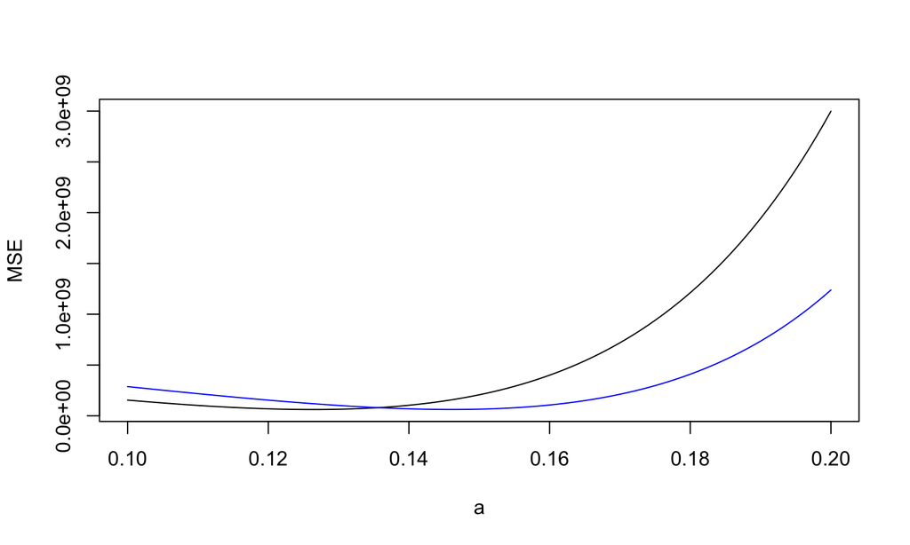

```r
curve(mse.plottable(a=x,y0=6611),from=0.10,to=0.20,xlab="a",ylab="MSE")
curve(mse.plottable(a=x,y0=5100),add=TRUE,col="blue")
```

## Example: curve()

Alternate strategy: `Vectorize()` returns a new, vectorized function

```r
mse.vec <- Vectorize(mse, vectorize.args=c("y0","a"))
mse.vec(a=seq(from=0.10,to=0.15,by=0.01),y0=6611)
```

```
## [1] 154701953 102322974  68755654  64529166 104079527 207057513
```

```r
mse.vec(a=1/8,y0=c(5000,6000,7000))
```

```
## [1] 134617132  74693733  63732256
```

## Example: curve()

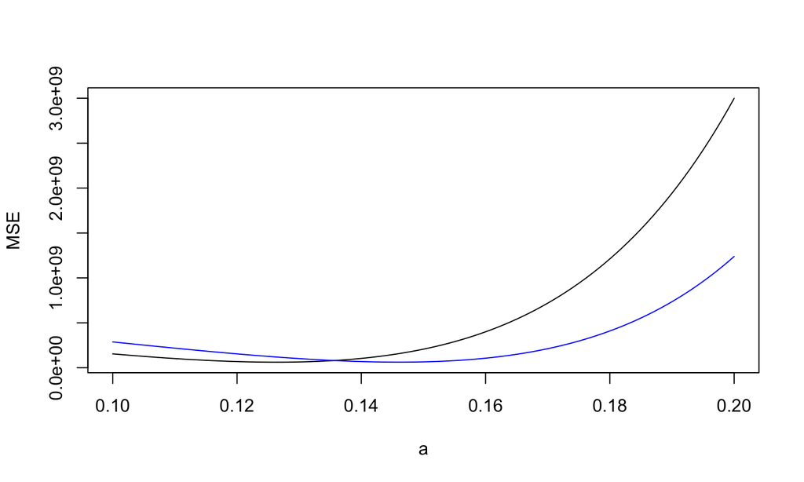

```r
curve(mse.vec(a=x,y0=6611),from=0.10,to=0.20,xlab="a",ylab="MSE")
curve(mse.vec(a=x,y0=5100),add=TRUE,col="blue")
```

## Optimization

## Examples of Optimization Problems

- Minimize mean-squared error of regression surface
- Maximize likelihood of distribution
- Maximize output of tanks from given supplies and factories
- Maximize return of portfolio for given volatility
- Minimize cost of airline flight schedule
- Maximize reproductive fitness of an organism

http://www.benfrederickson.com/numerical-optimization/

https://www.youtube.com/watch?v=x2KbdoxrQ6o

## Optimization Problems

Given an **objective function** $f: \mathcal{D} \mapsto R$, find

$$\DeclareMathOperator*{\argmax}{argmax}
\DeclareMathOperator*{\argmin}{argmin}
\theta^* = \argmin_{\theta}{f(\theta)}$$

Basics: maximizing $f$ is minimizing $-f$:

$$\argmax_{\theta}{f(\theta)}= \argmin_{\theta}{-f(\theta)}$$

If $h$ is strictly increasing (e.g., $\log$), then

$$\argmin_{\theta}{f(\theta)} = \argmin_{\theta}{h(f(\theta))}$$

## Considerations

- Approximation: How close can we get to $\theta^*$, and/or $f(\theta^*)$?
- Time complexity: How many computer steps does that take? Varies with precision of approximation, niceness of $f$, size of $\mathcal{D}$, size of data, method…
- Most optimization algorithms use **successive approximation**, so distinguish number of iterations from cost of each iteration

## Use calculus

Suppose $x$ is one dimensional and $f$ is smooth. If $x^*$ is an **interior** minimum / maximum / extremum point

$${\left. \frac{df}{dx} \right|}_{x=x^*} = 0$$

If $x^*$ a minimum,

$${\left. \frac{d^2f}{dx^2}\right|}_{x=x^*} > 0$$

## Use calculus

This all carries over to multiple dimensions: At an **interior extremum**,

$$\nabla f(\theta^*) = 0$$

At an **interior minimum**,

$$\nabla^2 f(\theta^*) \geq 0$$
meaning for any vector $v$,
$$v^T \nabla^2 f(\theta^*) v \geq 0$$
$\nabla^2 f =$ the **Hessian**, $\mathbf{H}$ $\theta$ might just be a **local** minimum

## Gradient Descent

$$f^{\prime}(x_0) = {\left. \frac{df}{dx}\right|}_{x=x_0} = \lim_{x\rightarrow x_0}{\frac{f(x)-f(x_0)}{x-x_0}}$$
$$f(x) \approx f(x_0) +(x-x_0)f^{\prime}(x_0)$$
Locally, the function looks linear; to minimize a linear function, move down the slope

Multivariate version:

$$f(\theta) \approx f(\theta_0) + (\theta-\theta_0) \cdot \nabla f(\theta_0)$$
$\nabla f(\theta_0)$ points in the direction of fastest ascent at $\theta_0$

## Gradient Descent

1. Start with initial guess for $\theta$, step-size $\eta$
2. While ((not too tired) and (making adequate progress))
- Find gradient $\nabla f(\theta)$
- Set $\theta \leftarrow \theta - \eta \nabla f(\theta)$
1. Return final $\theta$ as approximate $\theta^*$ Variations: adaptively adjust $\eta$ to make sure of improvement or search along the gradient direction for minimum

## Gradient Descent

Pro:

- Moves in direction of greatest immediate improvement
- If $\eta$ is small enough, gets to a local minimum eventually, and then stops

Cons:

- "small enough" $\eta$ can be really, really small
- Slowness or zig-zagging if components of $\nabla f$ are very different sizes How much work do we need?

## Scaling

Big-$O$ notation:

$$h(x) = O(g(x))$$
means
$$\lim_{x\rightarrow\infty}{\frac{h(x)}{g(x)}} = c$$
for some $c \neq 0$

e.g., $x^2 - 5000x + 123456778 = O(x^2)$

e.g., $e^{x}/(1+e^{x}) = O(1)$

Useful to look at over-all scaling, hiding details Also done when the limit is $x\rightarrow 0$

## Gradient Descent

Pro:

- For nice $f$, $f(\theta) \leq f(\theta^*)+\epsilon$ in $O(\epsilon^{-2})$ iterations + For *very* nice $f$, only $O(\log{\epsilon^{-1}})$ iterations
- To get $\nabla f(\theta)$, take $p$ derivatives, $\therefore$ each iteration costs $O(p)$

Con:

- Taking derivatives can slow down as data grows — each iteration might really be $O(np)$

## Taylor Series

What if we do a quadratic approximation to $f$?

$$f(x) \approx f(x_0) + (x-x_0)f^{\prime}(x_0) + \frac{1}{2}(x-x_0)^2 f^{\prime\prime}(x_0)$$

Special cases of general idea of Taylor approximation

Simplifies if $x_0$ is a minimum since then $f^{\prime}(x_0) = 0$:

$$f(x) \approx f(x_0) + \frac{1}{2}(x-x_0)^2 f^{\prime\prime}(x_0)$$

Near a minimum, smooth functions look like parabolas

Carries over to the multivariate case:

$$f(\theta) \approx f(\theta_0) + (\theta-\theta_0) \cdot \nabla f(\theta_0) + \frac{1}{2}(\theta-\theta_0)^T \mathbf{H}(\theta_0) (\theta-\theta_0)$$

## Minimizing a Quadratic

If we know

$$f(x) = ax^2 + bx + c$$
we minimize exactly:
$$\begin{eqnarray*} 2ax^* + b & = & 0\\ x^* & = & \frac{-b}{2a} \end{eqnarray*}$$
If
$$f(x) = \frac{1}{2}a (x-x_0)^2 + b(x-x_0) + c$$
then
$$x^* = x_0 - a^{-1}b$$

## Newton's Method

Taylor-expand for the value *at the minimum* $\theta^*$

$$f(\theta^*) \approx f(\theta) + (\theta^*-\theta) \nabla f(\theta) + \frac{1}{2}(\theta^*-\theta)^T \mathbf{H}(\theta) (\theta^*-\theta)$$
Take gradient, set to zero, solve for $\theta^*$:
$$\begin{eqnarray*} 0 & = & \nabla f(\theta) + \mathbf{H}(\theta) (\theta^*-\theta) \\ \theta^* & = & \theta - {\left(\mathbf{H}(\theta)\right)}^{-1} \nabla f(\theta) \end{eqnarray*}$$
Works *exactly* if $f$ is quadratic and $\mathbf{H}^{-1}$ exists, etc.

If $f$ isn't quadratic, keep pretending it is until we get close to $\theta^*$, when it will be nearly true

## Newton's Method

The Algorithm

1. Start with guess for $\theta$
2. While ((not too tired) and (making adequate progress))
- Find gradient $\nabla f(\theta)$ and Hessian $\mathbf{H}(\theta)$
- Set $\theta \leftarrow \theta - \mathbf{H}(\theta)^{-1} \nabla f(\theta)$
1. Return final $\theta$ as approximation to $\theta^*$

Like gradient descent, but with inverse Hessian giving the step-size

"This is about how far you can go with that gradient"

## Newton's Method

Pros:

- Step-sizes chosen adaptively through 2nd derivatives, much harder to get zig-zagging, over-shooting, etc.
- Also guaranteed to need $O(\epsilon^{-2})$ steps to get within $\epsilon$ of optimum
- Only $O(\log\log{\epsilon^{-1}})$ for very nice functions
- Typically many fewer iterations than gradient descent

## Newton's Method

Cons:

- Hopeless if $\mathbf{H}$ doesn't exist or isn't invertible
- Need to take $O(p^2)$ second derivatives *plus* $p$ first derivatives
- Need to solve $\mathbf{H} \theta_{\mathrm{new}} = \mathbf{H} \theta_{\mathrm{old}} - \nabla f(\theta_{\mathrm{old}})$ for $\theta_{\mathrm{new}}$
- Inverting $\mathbf{H}$ is $O(p^3)$, but cleverness gives $O(p^2)$ for solving for $\theta_{\mathrm{new}}$

## Getting Around the Hessian

Want to use the Hessian to improve convergence, but don't want to have to keep computing the Hessian at each step

Approaches:

- Use knowledge of the system to get some approximation to the Hessian, use that instead of taking derivatives ("Fisher scoring")
- Use only diagonal entries ($p$ unmixed 2nd derivatives)
- Use $\mathbf{H}(\theta)$ at initial guess, hope $\mathbf{H}$ changes *very* slowly with $\theta$
- Re-compute $\mathbf{H}(\theta)$ every $k$ steps, $k > 1$
- Fast, approximate updates to the Hessian at each step ([BFGS](https://en.wikipedia.org/wiki/Broyden%C3%A2%E2%82%AC%E2%80%9CFletcher%C3%A2%E2%82%AC%E2%80%9CGoldfarb%C3%A2%E2%82%AC%E2%80%9CShanno_algorithm))
- Lots of other methods!
- Nedler-Mead, a.k.a. "the simplex method", which doesn't need any derivatives

## Nelder-Mead

Try to cage $\theta^*$ with a **simplex** of $p+1$ points

Order the trial points, $f(\theta_1) \leq f(\theta_2) \ldots \leq f(\theta_{p+1})$

$\theta_{p+1}$ is the worst guess — try to improve it

Center of the not-worst = $\theta_0 = \frac{1}{n}\sum_{i=1}^{n}{\theta_i}$

## Nelder-Mead

Try to improve the worst guess $\theta_{p+1}$

1. **Reflection**: Try $\theta_0 - (\theta_{p+1}-\theta_0)$, across the center from $\theta_{p+1}$
- if it's better than $\theta_p$ but not than $\theta_1$, replace the old $\theta_{p+1}$ with it
- **Expansion**: if the reflected point is the new best, try $\theta_0 - 2(\theta_{p+1}-\theta_0)$; replace the old $\theta_{p+1}$ with the better of the reflected and the expanded point
1. **Contraction**: If the reflected point is worse that $\theta_p$, try $\theta_0 + \frac{\theta_{p+1}-\theta_0}{2}$; if the contracted value is better, replace $\theta_{p+1}$ with it
2. **Reduction**: If all else fails, $\theta_i \leftarrow \frac{\theta_1 + \theta_i}{2}$
3. Go back to (1) until we stop improving or run out of time

## Making Sense of Nedler-Mead

The Moves:

- Reflection: try the opposite of the worst point
- Expansion: if that really helps, try it some more
- Contraction: see if we overshot when trying the opposite
- Reduction: if all else fails, try making each point more like the best point

## Making Sense of Nedler-Mead

Pros:

- Each iteration $\leq 4$ values of $f$, plus sorting (and sorting is at most $O(p\log{p})$, usually much better)
- No derivatives used, can even work for dis-continuous $f$

Con:

- Can need *many* more iterations than gradient methods

## Coordinate Descent

Gradient descent, Newton's method, simplex, etc., adjust all coordinates of $\theta$ at once — gets harder as the number of dimensions $p$ grows

**Coordinate descent**: never do more than 1D optimization

- Start with initial guess $\theta$
- While ((not too tired) and (making adequate progress))
- For $i \in (1:p)$
  - do 1D optimization over $i^{\mathrm{th}}$ coordinate of $\theta$, holding the others fixed
  - Update $i^{\mathrm{th}}$ coordinate to this optimal value
- Return final value of $\theta$

## Coordinate Descent

Cons:

- Needs a good 1D optimizer
- Can bog down for very tricky functions, especially with lots of interactions among variables

Pros:

- Can be extremely fast and simple

## Curve-Fitting by Optimizing

We have data $(x_1, y_1), (x_2, y_2), \ldots (x_n, y_n)$, and possible curves, $r(x;\theta)$ e.g.

- $r(x) = x \cdot \theta$
- $r(x) = \theta_1 x^{\theta_2}$
- $r(x) = \sum_{j=1}^{q}{\theta_j b_j(x)}$ for fixed "basis" functions $b_j$

## Curve-Fitting by Optimizing

Least-squares curve fitting:

$$\hat{\theta} = \argmin_{\theta}{\frac{1}{n}\sum_{i=1}^n{(y_i - r(x_i;\theta))^2}}$$

"Robust" curve fitting:

$$\hat{\theta} = \argmin_{\theta}{\frac{1}{n}\sum_{i=1}^{n}{\psi(y_i - r(x_i;\theta))}}$$

## Summary

- In R, functions are objects, and can be arguments to other functions
- Functions can also be returned by other functions
- Optimizaiton
- Trade-offs: complexity of iteration vs. number of iterations vs. precision of approximation
- Gradient descent: less complex iterations, more guarantees, less adaptive
- Newton: more complex iterations, but few of them for good functions, more adaptive, less robust
- Next time pre-built code like `optim` and `nls`